# Portfolio_PDF

Smacchia Leandro

4/27/2020

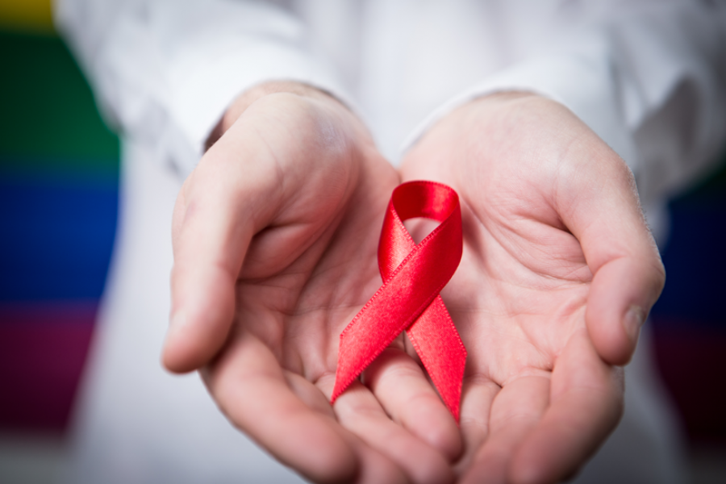

# HIV / A.I.D.S.

The Acquired Immune Deficiency Syndrome or **A.I.D.S.** is the associated disease of the Human Immunodefciency Virus commonly known as **HIV**. The HIV is part of the virus family called **retroviruses** which means it is an RNA virus that transcript his genes backwards to insert them in the host cell’s DNA. This has as a consequence that the host cell expresses viral genes like they were part of its initial genome. The HIV is spread by unprotected sex, blood transfusions, etc.

Infection by the HIV initiates with, after two to four weeks a stage of few or no symptoms which include fever, a flu-like illness, etc. It then develops and goes though another stage before reaching the final state of the infection : **A.I.D.S.**. People affected by A.I.D.S have low immunity and are thus subjects to various infections and tumors.

# My portfolio

Here, we are taking a look at this widespread disease for which we don’t have a cure yet. Indeed most person infected by the virus are treated with **antiretroviral therapy**. What i am trying to do and to share is **understanding the disease** with the newest informations about the virus and the last discoveries/studies. I also have a particular interest in new approaches to treatments like **gene therapy and other new treatments**.

The articles of this portfolio will be sorted in three categories :

- Understanding the disease
- Antiretroviral therapy
- Gene therapy and other new treatments

I hope this portfolio will entertain your interest and, i am sure, make you learn some things.